# Practical Machine Learning: Prediction Assignment

By: Adji Fatou Diagne

## Background

Using devices such as Jawbone Up, Nike FuelBand, and Fitbit it is now possible to collect a large amount of data about personal activity relatively inexpensively. These type of devices are part of the quantified self movement – a group of enthusiasts who take measurements about themselves regularly to improve their health, to find patterns in their behavior, or because they are tech geeks. One thing that people regularly do is quantify how much of a particular activity they do, but they rarely quantify how well they do it. In this project, your goal will be to use data from accelerometers on the belt, forearm, arm, and dumbell of 6 participants. They were asked to perform barbell lifts correctly and incorrectly in 5 different ways. More information on the data is available from the website [here.](http://groupware.les.inf.puc-rio.br/har) (see the section on the Weight Lifting Exercise Dataset.).

## Data

The training data for this project are available [here.](https://d396qusza40orc.cloudfront.net/predmachlearn/pml-training.csv)

The test data are available [here.](https://d396qusza40orc.cloudfront.net/predmachlearn/pml-testing.csv)

The data for this project come from this [source.](http://groupware.les.inf.puc-rio.br/har) with full citation of data is as follows.

Velloso, E.; Bulling, A.; Gellersen, H.; Ugulino, W.; Fuks, H. Qualitative Activity Recognition of Weight Lifting Exercises. Proceedings of 4th International Conference in Cooperation with SIGCHI (Augmented Human ’13) . Stuttgart, Germany: ACM SIGCHI, 2013

Six young health participants were asked to perform one set of 10 repetitions of the Unilateral Dumbbell Biceps Curl in five different fashions: exactly according to the specification (Class A), throwing the elbows to the front (Class B), lifting the dumbbell only halfway (Class C), lowering the dumbbell only halfway (Class D) and throwing the hips to the front (Class E).

Class A corresponds to the specified execution of the exercise, while the other 4 classes correspond to common mistakes. Participants were supervised by an experienced weight lifter to make sure the execution complied to the manner they were supposed to simulate. The exercises were performed by six male participants aged between 20-28 years, with little weight lifting experience. We made sure that all participants could easily simulate the mistakes in a safe and controlled manner by using a relatively light dumbbell (1.25kg).

In this project, I will predict as they did in the exercise on the aforementioned website.

## Part 1: Loading, Cleaning, and Exploring the Data

See code notes describing each step in the process

```r
## download necessary packages
library(caret)
library(e1071)
library(rpart)
library(randomForest)
```

```r
set.seed(1234)
#load datasets from urls
library(data.table)
fileUrl <- "https://d396qusza40orc.cloudfront.net/predmachlearn/pml-training.csv"
download.file(fileUrl, destfile = "train.csv")
Train_data <- read.csv("train.csv")

library(data.table)
fileUrl <- "https://d396qusza40orc.cloudfront.net/predmachlearn/pml-testing.csv"
download.file(fileUrl, destfile = "test.csv")
Test_data <- read.csv ("test.csv")
```

```r
inTrain <- createDataPartition(Train_data$classe, p=0.7, list=FALSE)
Train_set <- Train_data[inTrain, ]
Test_set <- Train_data[-inTrain, ]
dim(Train_data)
```

```
## [1] 19622   160
```

```r
dim(Test_set)
```

```
## [1] 5885  160
```

```r
#remove variables with Nearly Zero Variance
NZV <- nearZeroVar(Train_set)
Train_set <- Train_set[, -NZV]
Test_set <- Test_set[, -NZV]
dim(Train_set)
```

```
## [1] 13737   104
```

```r
#remove all missing values
Train_set <- Train_set[, colSums(is.na(Train_set)) == 0]
Test_set <- Test_set[, colSums(is.na(Test_set)) == 0]
dim(Train_set)
```

```
## [1] 13737    59
```

```r
dim(Test_set)
```

```
## [1] 5885   59
```

```r
#summary(Train_clean)
#remove identification only variables columns 1-7, these variables are unrelated to our variable of interest classe
Train_set <- Train_set[, -(1:7)]
Test_set <- Test_set[, -(1:7)]
dim(Train_set)
```

```
## [1] 13737    52
```

```r
dim(Test_set)
```

```
## [1] 5885   52
```

```r
table(Train_set$classe)
```

```
##
##    A    B    C    D    E
## 3906 2658 2396 2252 2525
```

## Part 2: Prediction Analysis

We can perform classification methods using random forest and a decision tree algorithm from the caret package for our prediction models. In doing so, we build a 3-fold cross validation model to use for our classification fits.

```r
set.seed(12345)
#fit CV model
CV_model <- trainControl(method="cv", number=3, verboseIter=FALSE)
#fit Random Forest model
RF_model <- train(classe ~ ., data=Train_set, method="rf",
                          trControl=CV_model)
RF_model$finalModel
```

```
##
## Call:
##  randomForest(x = x, y = y, mtry = param$mtry)
##                Type of random forest: classification
##                      Number of trees: 500
## No. of variables tried at each split: 26
##
##         OOB estimate of  error rate: 0.68%
## Confusion matrix:
##      A    B    C    D    E class.error
## A 3902    3    0    0    1 0.001024066
## B   21 2629    6    1    1 0.010910459
## C    0   15 2374    7    0 0.009181970
## D    0    1   25 2224    2 0.012433393
## E    0    1    3    7 2514 0.004356436
```

```r
#predict random forest model
predict_RF <- predict(RF_model, newdata=Test_set)
confMatrix_RF <- confusionMatrix(factor(predict_RF), factor(Test_set$classe))
confMatrix_RF
```

```
## Confusion Matrix and Statistics
##
##           Reference
## Prediction    A    B    C    D    E
##          A 1674    9    0    0    0
##          B    0 1130    5    1    0
##          C    0    0 1018    5    1
##          D    0    0    3  957    1
##          E    0    0    0    1 1080
##
## Overall Statistics
##
##                Accuracy : 0.9956
##                  95% CI : (0.9935, 0.9971)
##     No Information Rate : 0.2845
##     P-Value [Acc > NIR] : < 2.2e-16
##
##                   Kappa : 0.9944
##
##  Mcnemar's Test P-Value : NA
##
## Statistics by Class:
##
##                      Class: A Class: B Class: C Class: D Class: E
## Sensitivity            1.0000   0.9921   0.9922   0.9927   0.9982
## Specificity            0.9979   0.9987   0.9988   0.9992   0.9998
## Pos Pred Value         0.9947   0.9947   0.9941   0.9958   0.9991
## Neg Pred Value         1.0000   0.9981   0.9984   0.9986   0.9996
## Prevalence             0.2845   0.1935   0.1743   0.1638   0.1839
## Detection Rate         0.2845   0.1920   0.1730   0.1626   0.1835
## Detection Prevalence   0.2860   0.1930   0.1740   0.1633   0.1837
## Balanced Accuracy      0.9989   0.9954   0.9955   0.9960   0.9990
```

The confusion matrix accuracy is 0.9956 for the Random Forest model which is pretty good for our production. The plot below provides a visual of the prediction outcome.

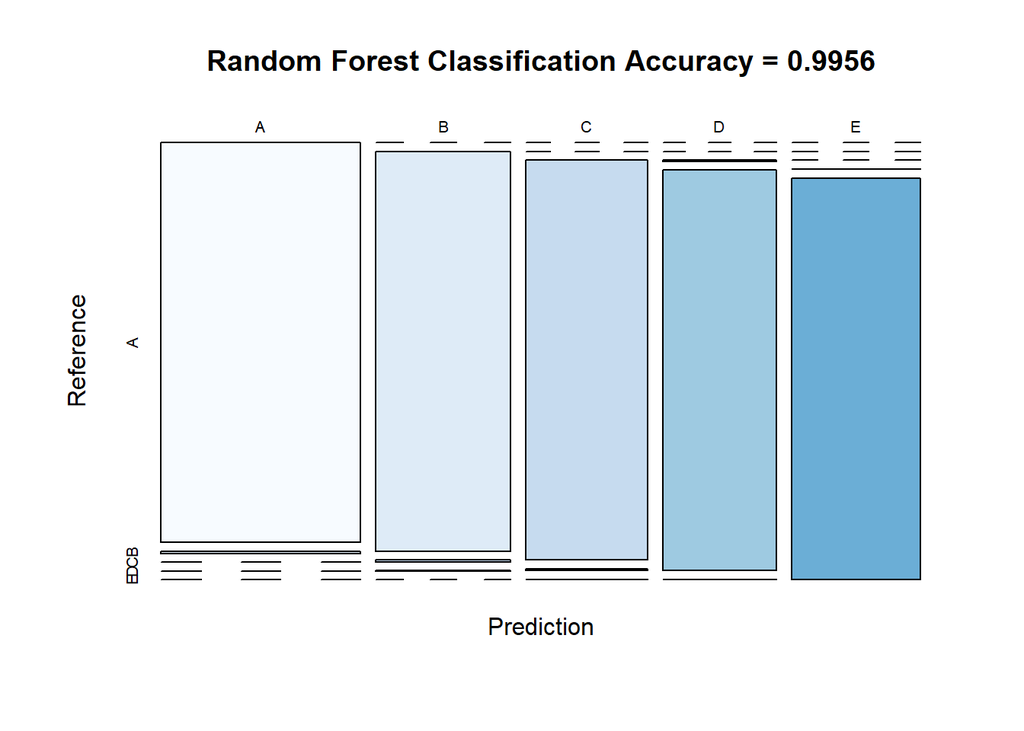

```r
#plot confusion matrix accuracy
plot(confMatrix_RF$table, col = blues9,
     main = paste("Random Forest Classification Accuracy =",
                  round(confMatrix_RF$overall['Accuracy'], 4)))
```

Next, we will predict using a Decision Tree model on the training dataset.

```r
#fit decision tree model
set.seed(12345)
Tree_model <- rpart(classe ~ ., data=Train_set, method="class")
```

```r
#predict classification tree model
predict_Tree <- predict(Tree_model, newdata=Test_set, type="class")
confMatrix_Tree <- confusionMatrix(factor(predict_Tree), factor(Test_set$classe))
confMatrix_Tree
```

```
## Confusion Matrix and Statistics
##
##           Reference
## Prediction    A    B    C    D    E
##          A 1440  138   11   18   67
##          B   45  727   62   58   80
##          C    8   89  766  137  111
##          D  156   76   37  628   95
##          E   25  109  150  123  729
##
## Overall Statistics
##
##                Accuracy : 0.729
##                  95% CI : (0.7174, 0.7403)
##     No Information Rate : 0.2845
##     P-Value [Acc > NIR] : < 2.2e-16
##
##                   Kappa : 0.6574
##
##  Mcnemar's Test P-Value : < 2.2e-16
##
## Statistics by Class:
##
##                      Class: A Class: B Class: C Class: D Class: E
## Sensitivity            0.8602   0.6383   0.7466   0.6515   0.6738
## Specificity            0.9444   0.9484   0.9290   0.9260   0.9153
## Pos Pred Value         0.8602   0.7479   0.6895   0.6331   0.6417
## Neg Pred Value         0.9444   0.9161   0.9455   0.9313   0.9257
## Prevalence             0.2845   0.1935   0.1743   0.1638   0.1839
## Detection Rate         0.2447   0.1235   0.1302   0.1067   0.1239
## Detection Prevalence   0.2845   0.1652   0.1888   0.1686   0.1930
## Balanced Accuracy      0.9023   0.7933   0.8378   0.7887   0.7945
```

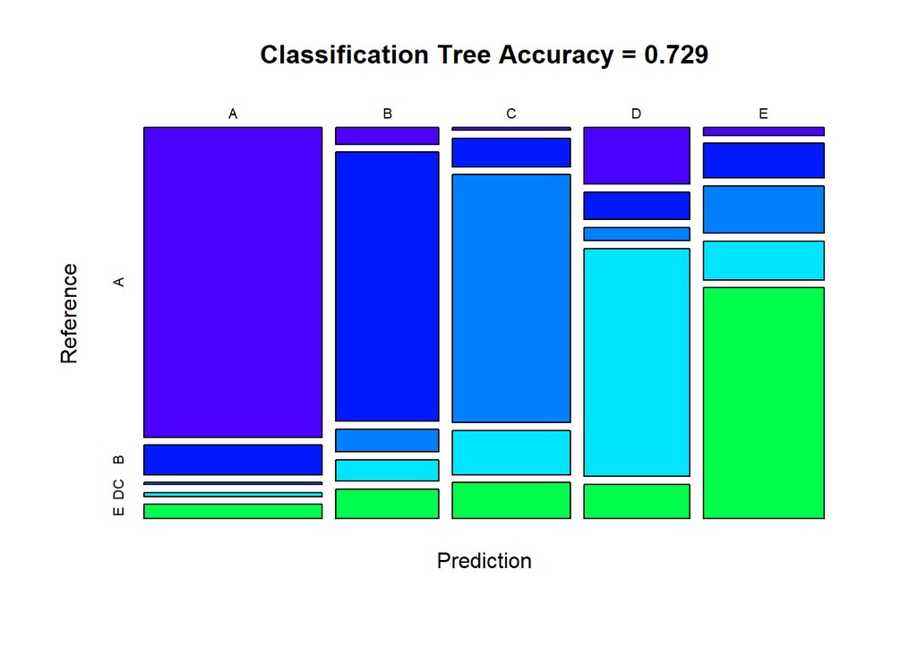

```r
#plot confusion matrix results to test performance
plot(confMatrix_Tree$table, col = topo.colors(10),
     main = paste("Classification Tree Accuracy =",
                  round(confMatrix_Tree$overall['Accuracy'], 4)))
```

## Final Results of Prediction and Conclusion

It appears from the results above that the Random Forest model has the best accuracy for the testing dataset so we will predict as follow;

```r
#predict results for 20 different test cases (test dataset)
predict_results <- predict(RF_model, newdata=Test_data)
#print prediction results
predict_results
```

```
##  [1] B A B A A E D B A A B C B A E E A B B B
## Levels: A B C D E
```